# ARIMA Models in R

Recall that you use the ACF and PACF pair to help identify the orders $p$ and $q$ of an ARMA model.

In this exercise, you will generate data from the AR(1) model,

$X_t=.9X_{t−1}+W_t$,

look at the simulated data and the sample ACF and PACF pair to determine the order. Then, you will fit the model and compare the estimated parameters to the true parameters.

Throughout this course, you will be using `sarima()` from the [astsa](https://www.rdocumentation.org/packages/astsa/versions/1.6/) package to easily fit models to data. The command produces a residual diagnostic graphic that can be ignored until diagnostics is discussed later in the chapter.

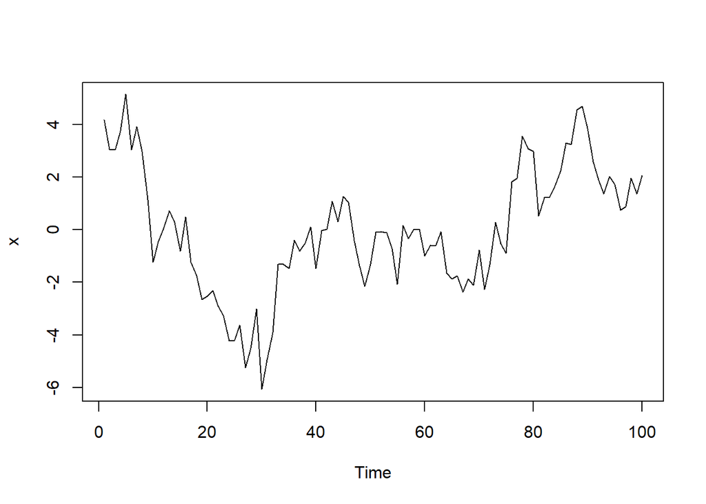

```r
# Generate 100 observations from the AR(1) model
x <- arima.sim(model = list(order = c(1, 0, 0), ar = .9), n = 100)

# Plot the generated data
plot(x)
```

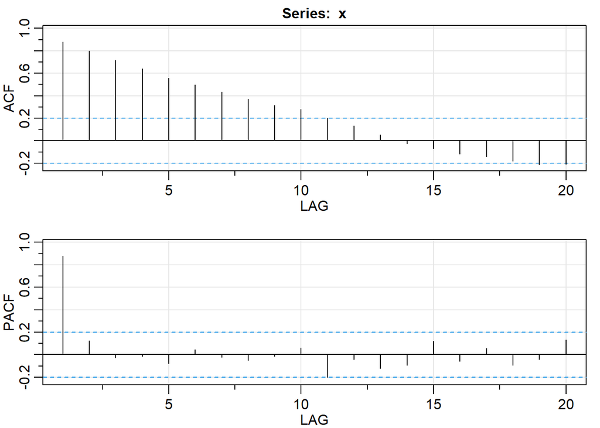

```
##      [,1] [,2]  [,3]  [,4]  [,5] [,6]  [,7]  [,8]  [,9] [,10] [,11] [,12] [,13]
## ACF  0.88 0.80  0.72  0.64  0.56 0.50  0.43  0.37  0.31  0.28   0.2  0.13  0.05
## PACF 0.88 0.12 -0.03 -0.02 -0.08 0.04 -0.02 -0.05 -0.01  0.06  -0.2 -0.04 -0.12
##      [,14] [,15] [,16] [,17] [,18] [,19] [,20]
## ACF  -0.03 -0.07 -0.12 -0.14 -0.18 -0.21 -0.21
## PACF -0.09  0.12 -0.06  0.06 -0.09 -0.04  0.13
```

```r
# Plot the sample P/ACF pair
astsa::acf2(x)
```

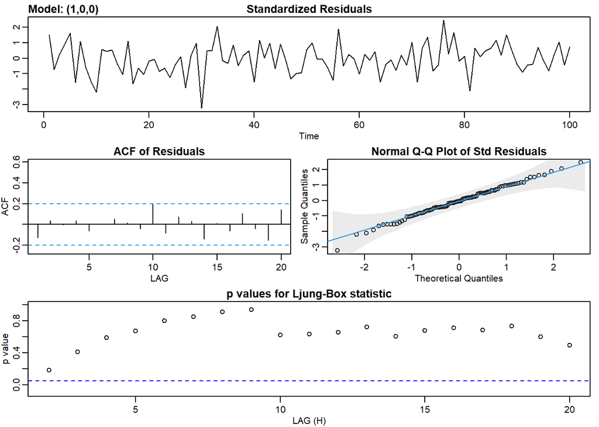

```
## $fit
##
## Call:
## stats::arima(x = xdata, order = c(p, d, q), seasonal = list(order = c(P, D,
##     Q), period = S), xreg = xmean, include.mean = FALSE, transform.pars = trans,
##     fixed = fixed, optim.control = list(trace = trc, REPORT = 1, reltol = tol))
##
## Coefficients:
##         ar1   xmean
##       0.903  0.4713
## s.e.  0.043  1.0156
##
## sigma^2 estimated as 1.105:  log likelihood = -147.75,  aic = 301.5
##
## $degrees_of_freedom
## [1] 98
##
## $ttable
##       Estimate     SE t.value p.value
## ar1     0.9030 0.0430 21.0132  0.0000
## xmean   0.4713 1.0156  0.4641  0.6436
##
## $AIC
## [1] 3.015005
##
## $AICc
## [1] 3.016242
##
## $BIC
## [1] 3.09316
```

```r
# Fit an AR(1) to the data and examine the t-table
astsa::sarima(x, p = 1, d = 0, q = 0)
```

As you can see, the `sarima()` command provides extensive output to understand the results of your model fit. What do you glean from this output?

**Fitting an AR(2) model**

For this exercise, we generated data from the AR(2) model,

$X_t=1.5X_{t−1}−.75X_{t−2}+W_t$

Look at the simulated dataand the sample ACF and PACF pair to determine the model order. Then fit the model and compare the estimated parameters to the true parameters.

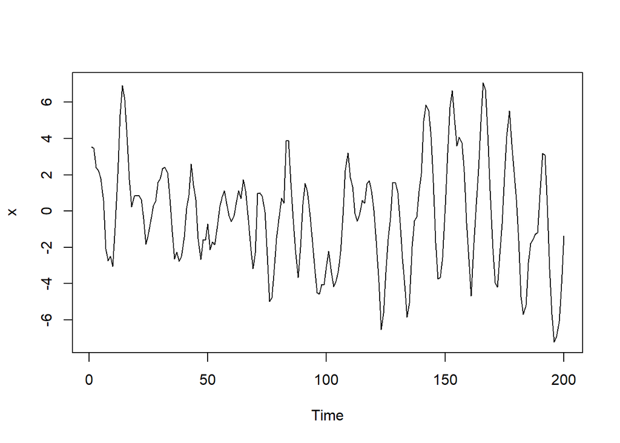

```r
x <- arima.sim(model = list(order = c(2, 0, 0), ar = c(1.5, -.75)), n = 200)

# Plot x
plot(x)
```

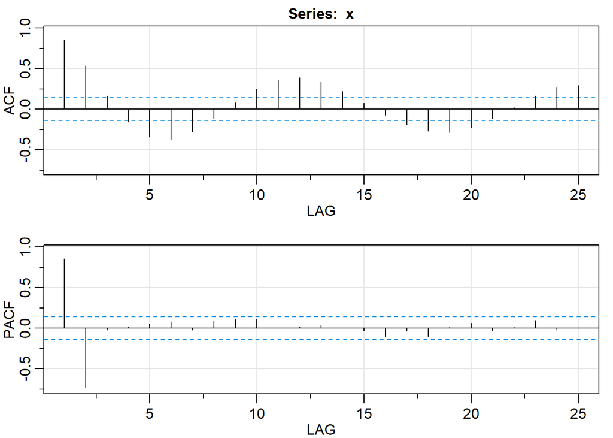

```
##      [,1]  [,2]  [,3]  [,4]  [,5]  [,6]  [,7]  [,8] [,9] [,10] [,11] [,12]
## ACF  0.85  0.53  0.16 -0.15 -0.34 -0.37 -0.28 -0.11 0.08  0.25  0.36  0.39
## PACF 0.85 -0.73 -0.02  0.02  0.05  0.08 -0.02  0.09 0.11  0.11  0.01  0.01
##      [,13] [,14] [,15] [,16] [,17] [,18] [,19] [,20] [,21] [,22] [,23] [,24]
## ACF   0.33  0.22  0.08 -0.07 -0.19 -0.27 -0.29 -0.23 -0.12  0.02  0.16  0.26
## PACF  0.04  0.01 -0.03 -0.10 -0.03 -0.10  0.01  0.06 -0.03  0.02  0.10 -0.02
##      [,25]
## ACF   0.29
## PACF  0.00
```

```r
# Plot the sample P/ACF of x
astsa::acf2(x)
```

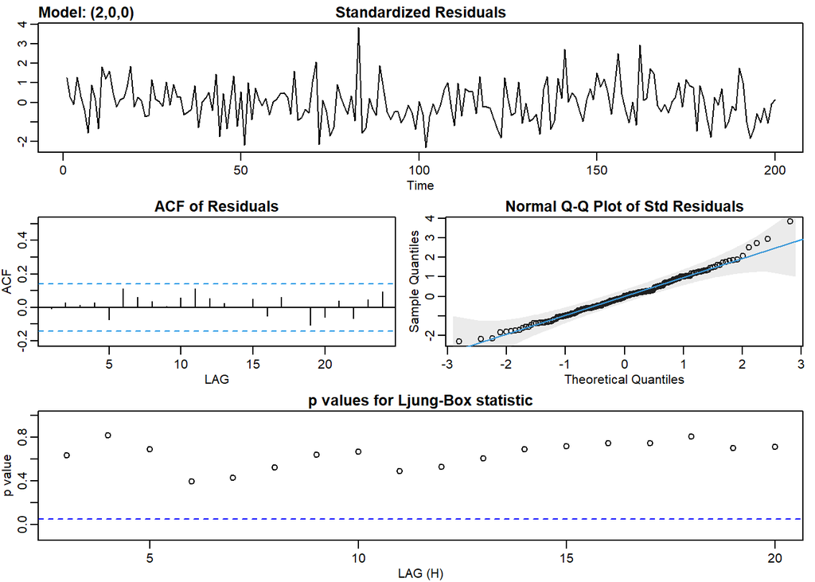

```
## $fit
##
## Call:
## stats::arima(x = xdata, order = c(p, d, q), seasonal = list(order = c(P, D,
##     Q), period = S), xreg = xmean, include.mean = FALSE, transform.pars = trans,
##     fixed = fixed, optim.control = list(trace = trc, REPORT = 1, reltol = tol))
##
## Coefficients:
##          ar1      ar2    xmean
##       1.5035  -0.7536  -0.1930
## s.e.  0.0463   0.0465   0.2836
##
## sigma^2 estimated as 1.006:  log likelihood = -285.85,  aic = 579.71
##
## $degrees_of_freedom
## [1] 197
##
## $ttable
##       Estimate     SE  t.value p.value
## ar1     1.5035 0.0463  32.4714  0.0000
## ar2    -0.7536 0.0465 -16.2154  0.0000
## xmean  -0.1930 0.2836  -0.6806  0.4969
##
## $AIC
## [1] 2.898527
##
## $AICc
## [1] 2.89914
##
## $BIC
## [1] 2.964494
```

```r
# Fit an AR(2) to the data and examine the t-table
astsa::sarima(x, p = 2, d = 0, q = 0)
```

As you can see from the t-table output, the estimates produced by the `sarima()` command are close to the true parameters.

**Fitting an MA(1) model**

In this exercise, we generated data from an MA(1) model,

$X_t=W_t−.8W_{t−1}$

Recall that for pure MA(q) models, the theoretical ACF will cut off at lag q while the PACF will tail off.

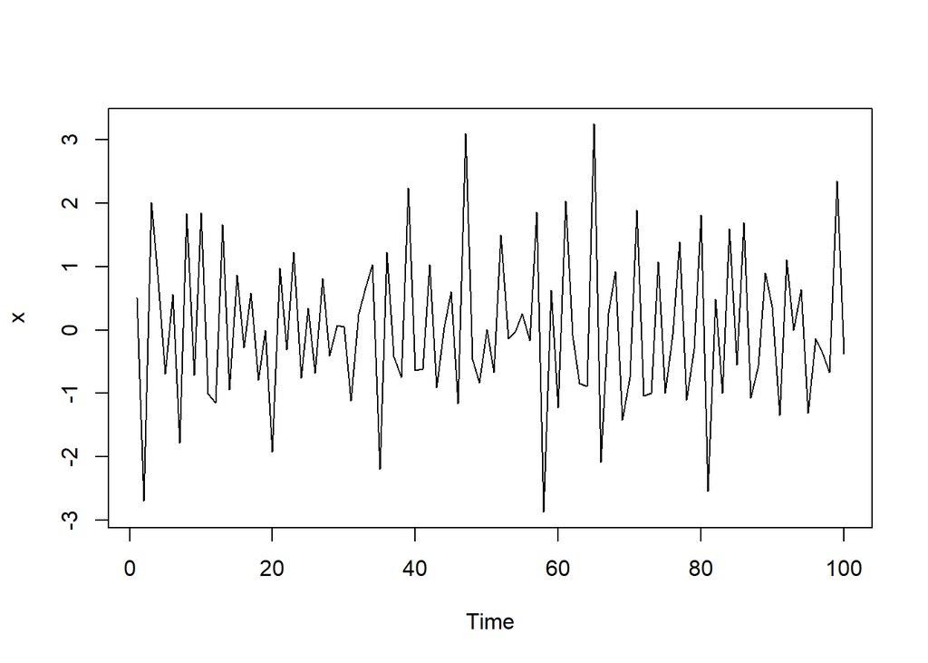

```r
x <- arima.sim(model = list(order = c(0, 0, 1), ma = -.8), n = 100)

# Plot x
plot(x)
```

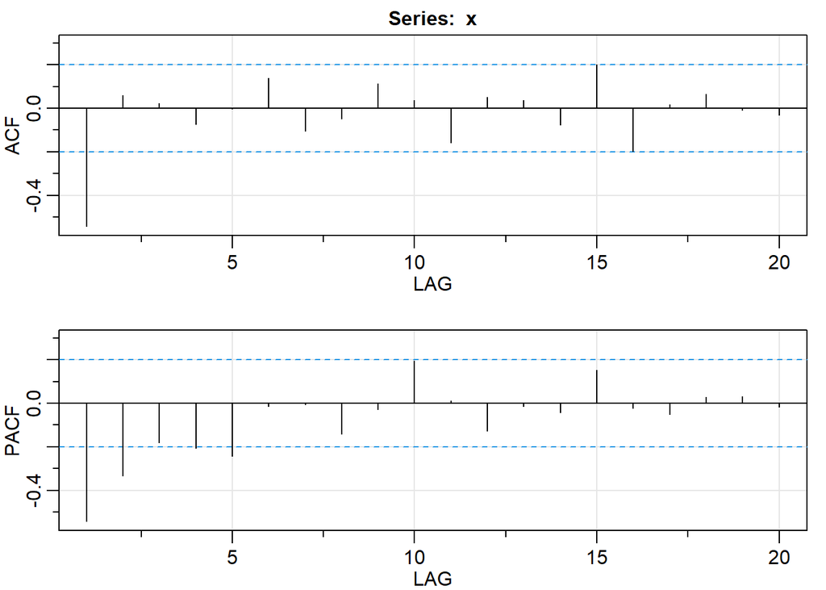

```
##       [,1]  [,2]  [,3]  [,4]  [,5]  [,6]  [,7]  [,8]  [,9] [,10] [,11] [,12]
## ACF  -0.54  0.06  0.02 -0.07  0.00  0.14 -0.10 -0.05  0.11  0.04 -0.16  0.05
## PACF -0.54 -0.33 -0.18 -0.21 -0.24 -0.01 -0.01 -0.14 -0.03  0.19  0.01 -0.13
##      [,13] [,14] [,15] [,16] [,17] [,18] [,19] [,20]
## ACF   0.04 -0.07  0.20 -0.20  0.02  0.07 -0.01 -0.03
## PACF -0.01 -0.04  0.15 -0.02 -0.05  0.03  0.03 -0.02
```

```r
# Plot the sample P/ACF of x
acf2(x)
```

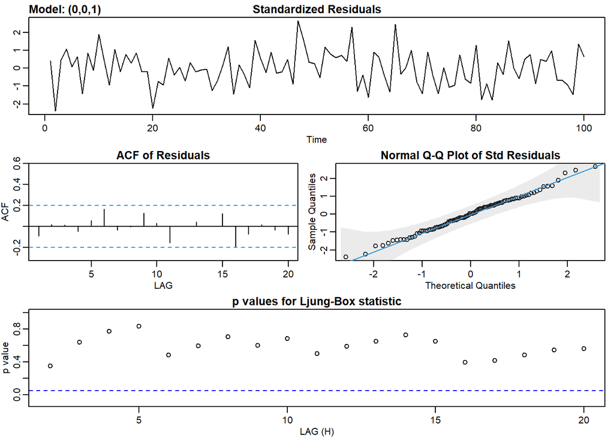

```
## $fit
##
## Call:
## stats::arima(x = xdata, order = c(p, d, q), seasonal = list(order = c(P, D,
##     Q), period = S), xreg = xmean, include.mean = FALSE, transform.pars = trans,
##     fixed = fixed, optim.control = list(trace = trc, REPORT = 1, reltol = tol))
##
## Coefficients:
##           ma1   xmean
##       -0.7928  0.0131
## s.e.   0.0555  0.0199
##
## sigma^2 estimated as 0.853:  log likelihood = -134.44,  aic = 274.88
##
## $degrees_of_freedom
## [1] 98
##
## $ttable
##       Estimate     SE  t.value p.value
## ma1    -0.7928 0.0555 -14.2939  0.0000
## xmean   0.0131 0.0199   0.6585  0.5118
##
## $AIC
## [1] 2.74881
##
## $AICc
## [1] 2.750047
##
## $BIC
## [1] 2.826965
```

```r
# Fit an MA(1) to the data and examine the t-table
sarima(x, p = 0, d = 0, q = 1)
```

Once again, the parameter estimates produced by `sarima()` come quite close to the input specified when the data was created (-.8)

**AR and MA together: ARMA**

$X_t = \phi X_{t-1} + W_t + \theta W_{t-1}$ autoregression with correlated errors

**Fitting an ARMA model**

You are now ready to merge the AR model and the MA model into the ARMA model. We generated data from the ARMA(2,1) model,

$X_t= X_{t−1} − .9X_{t−2} + W_t + .8W_{t−1}$,

```
x <- arima.sim(model = list(order = c(2, 0, 1), ar = c(1, -.9), ma = .8), n = 250).
```

Look at the simulated data and the sample ACF and PACF pair to determine a possible model.

Recall that for $ARMA(p,q)$ models, both the theoretical ACF and PACF tail off. In this case, the orders are difficult to discern from data and it may not be clear if either the sample ACF or sample PACF is cutting off or tailing off. In this case, you know the actual model orders, so fit an ARMA(2,1) to the generated data. General modeling strategies will be discussed further in the course.

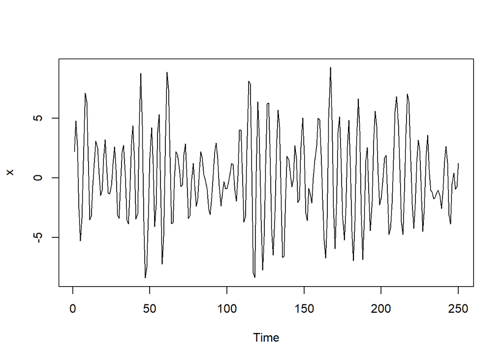

```r
x <- arima.sim(model = list(order = c(2, 0, 1), ar = c(1, -.9), ma = .8), n = 250)

# astsa is preloaded

# Plot x
plot(x)
```

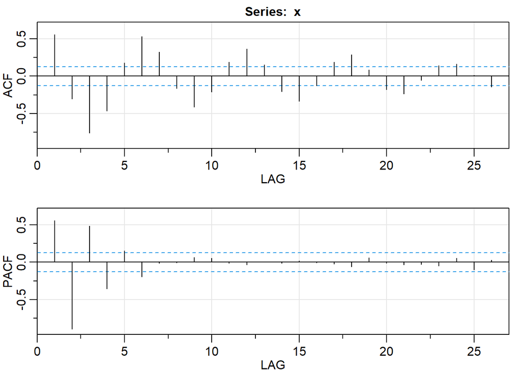

```
##      [,1]  [,2]  [,3]  [,4] [,5]  [,6]  [,7]  [,8]  [,9] [,10] [,11] [,12]
## ACF  0.56 -0.31 -0.76 -0.47 0.18  0.53  0.32 -0.16 -0.41 -0.21  0.19  0.36
## PACF 0.56 -0.90  0.48 -0.36 0.15 -0.20 -0.02 -0.01  0.06  0.05 -0.02 -0.04
##      [,13] [,14] [,15] [,16] [,17] [,18] [,19] [,20] [,21] [,22] [,23] [,24]
## ACF   0.15 -0.21 -0.34 -0.13  0.19  0.29  0.09 -0.18 -0.23 -0.06  0.14  0.16
## PACF  0.00 -0.01  0.02 -0.01 -0.02 -0.06  0.06 -0.01 -0.03 -0.03 -0.05  0.05
##      [,25] [,26]
## ACF   0.01 -0.14
## PACF -0.10  0.03
```

```r
# Plot the sample P/ACF of x
astsa::acf2(x)
```

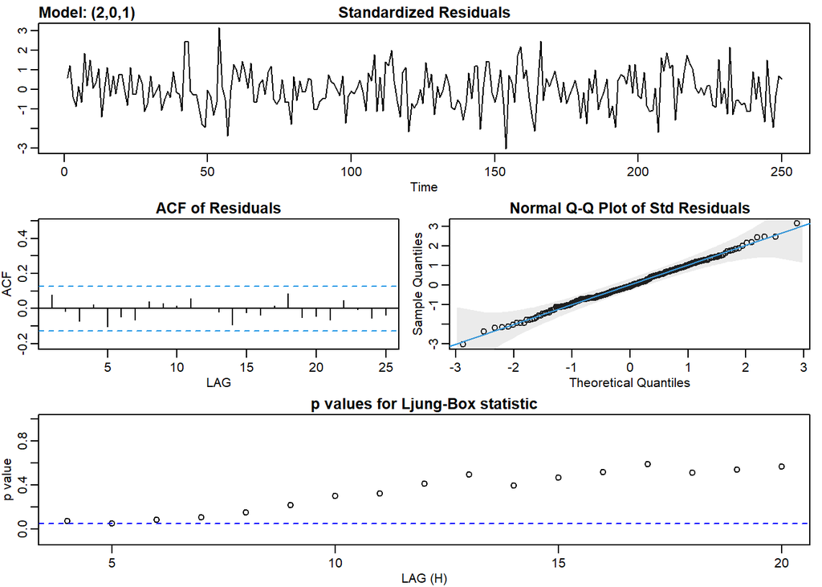

```
## $fit
##
## Call:
## stats::arima(x = xdata, order = c(p, d, q), seasonal = list(order = c(P, D,
##     Q), period = S), xreg = xmean, include.mean = FALSE, transform.pars = trans,
##     fixed = fixed, optim.control = list(trace = trc, REPORT = 1, reltol = tol))
##
## Coefficients:
##         ar1      ar2     ma1   xmean
##       0.972  -0.8534  0.7595  0.0502
## s.e.  0.033   0.0324  0.0378  0.1278
##
## sigma^2 estimated as 1.021:  log likelihood = -360.01,  aic = 730.01
##
## $degrees_of_freedom
## [1] 246
##
## $ttable
##       Estimate     SE  t.value p.value
## ar1     0.9720 0.0330  29.4939  0.0000
## ar2    -0.8534 0.0324 -26.3164  0.0000
## ma1     0.7595 0.0378  20.0785  0.0000
## xmean   0.0502 0.1278   0.3929  0.6947
##
## $AIC
## [1] 2.920052
##
## $AICc
## [1] 2.920705
##
## $BIC
## [1] 2.990481
```

```r
# Fit an ARMA(2,1) to the data and examine the t-table
astsa::sarima(x, p = 2, d = 0, q = 1)
```

As you can see, the `sarima()` command can estimate parameter values for many different types of models, including AR, MA, and ARMA.

**Identify an ARMA model**

Look at (1) the data plots and (2) the sample ACF and PACF of the logged and differenced varve series:

```
dl_varve <- diff(log(astsa::varve))
```

Use help(varve) to read about the data or use an internet search on varve to learn more.

From the ACF and PACF, which model is the most likely model for `dl_varve`?

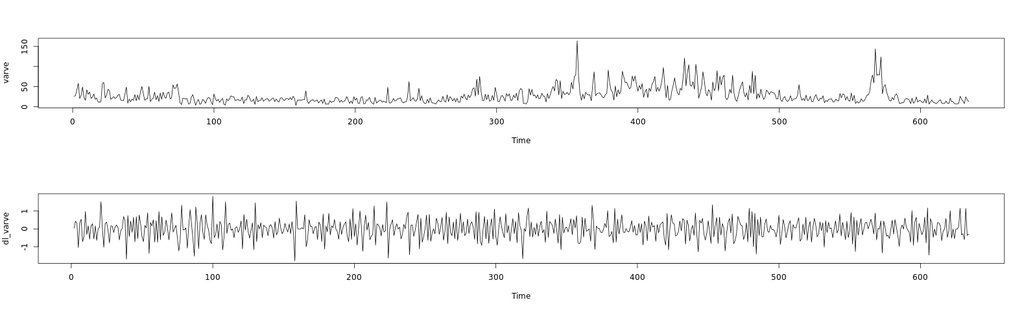

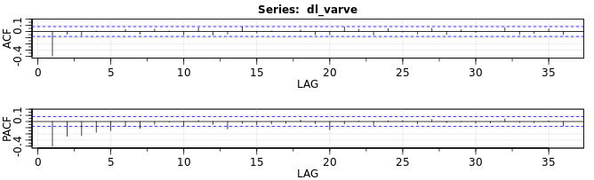

Remember that an MA(q) model has an ACF that cuts off at lag q and a PACF that tails off. In this case, the ACF cuts off at lag 1 and the PACF tails off, suggesting an MA(1) model.

**Model choice and residual analysis**

**AIC and BIC**

| Error |  | Number of Parameters |
| --- | --- | --- |
| $\textit{average(observed-predicted)}^\textit{2}$ | + | $\textit{k(p+q)}$ |

- AIC and BIC measure the error and penalize (differently) for adding parameters
- for example AIC has *k = 2* and BIC has *k = log(n)*
- Goal: find the model with the smallest AIC or BIC

**Residual Analysis**

`sarima()` includes residual analysis and graphic showing:

1. Standardized residuals
- should be white noise
2. Sample ACF of residuals
- points within blue lines indicates normality
3. Normal Q-Q plot
- points should mostly be on the line
4. Q-statistic p-values
- points above blue line indicates normality

**Model choice - I** Based on the sample P/ACF pair of the logged and differenced varve data (`dl_varve`), an MA(1) was indicated. The best approach to fitting ARMA is to start with a low order model, and then try to add a parameter at a time to see if the results change.

In this exercise, you will fit various models to the `dl_varve` data and note the AIC and BIC for each model. In the next exercise, you will use these AICs and BICs to choose a model. Remember that you want to retain the model with the smallest AIC and/or BIC value.

A note before you start:

`sarima(x, p = 0, d = 0, q = 1)` and `sarima(x, 0, 0, 1)`

are the same.

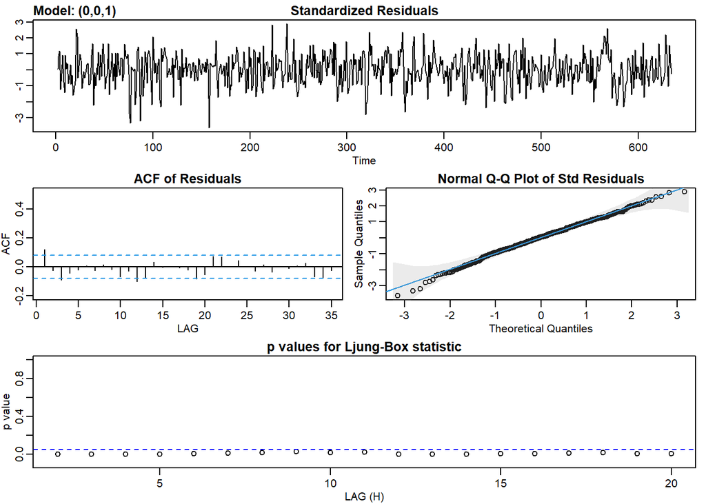

```
## $fit
##
## Call:
## stats::arima(x = xdata, order = c(p, d, q), seasonal = list(order = c(P, D,
##     Q), period = S), xreg = xmean, include.mean = FALSE, transform.pars = trans,
##     fixed = fixed, optim.control = list(trace = trc, REPORT = 1, reltol = tol))
##
## Coefficients:
##           ma1    xmean
##       -0.7710  -0.0013
## s.e.   0.0341   0.0044
##
## sigma^2 estimated as 0.2353:  log likelihood = -440.68,  aic = 887.36
##
## $degrees_of_freedom
## [1] 631
##
## $ttable
##       Estimate     SE  t.value p.value
## ma1    -0.7710 0.0341 -22.6002  0.0000
## xmean  -0.0013 0.0044  -0.2818  0.7782
##
## $AIC
## [1] 1.401826
##
## $AICc
## [1] 1.401856
##
## $BIC
## [1] 1.422918
```

```r
dl_varve <- diff(log(astsa::varve))

# Fit an MA(1) to dl_varve.
sarima(dl_varve, p = 0, d = 0, q = 1)
```

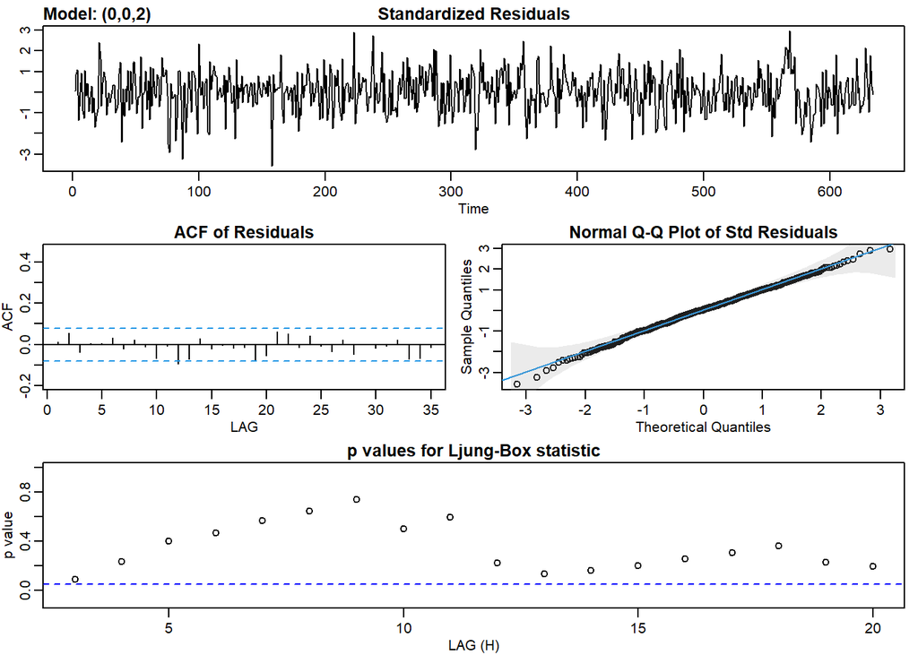

```
## $fit
##
## Call:
## stats::arima(x = xdata, order = c(p, d, q), seasonal = list(order = c(P, D,
##     Q), period = S), xreg = xmean, include.mean = FALSE, transform.pars = trans,
##     fixed = fixed, optim.control = list(trace = trc, REPORT = 1, reltol = tol))
##
## Coefficients:
##           ma1      ma2    xmean
##       -0.6710  -0.1595  -0.0013
## s.e.   0.0375   0.0392   0.0033
##
## sigma^2 estimated as 0.2294:  log likelihood = -432.69,  aic = 873.39
##
## $degrees_of_freedom
## [1] 630
##
## $ttable
##       Estimate     SE  t.value p.value
## ma1    -0.6710 0.0375 -17.9057  0.0000
## ma2    -0.1595 0.0392  -4.0667  0.0001
## xmean  -0.0013 0.0033  -0.4007  0.6888
##
## $AIC
## [1] 1.379757
##
## $AICc
## [1] 1.379817
##
## $BIC
## [1] 1.40788
```

```r
# Fit an MA(2) to dl_varve. Improvement?
sarima(dl_varve, p = 0, d = 0, q = 2)
```